# Bootstrap in R for Engineers and Geoscientists

#### Author: [@GeostatsGuy](https://twitter.com/geostatsguy) | [GitHub/GeostatsGuy](https://github.com/GeostatsGuy)

A very simple demonstration of Bootstrap (boot package by Canty, A. and Ripley, B., 2017), the docs are at https://cran.r-project.org/web/packages/boot/boot.pdf. For this example a “toy datatset” of 5 porosity values is generated. I used this in my Introduction to Geostatistics Undergraduate Class (PGE337 at UT Austin) as a first introduction to R for the engineering undergraduate students. It is assumed that students have no previous R experience; therefore, all steps of the code are explored and described.

#### Load the required libraries

We load the boot library for the bootstrap (boot) command and plyr is convenient for data manipulation.

```r
library(boot)                                  # the package for bootstrap by Angelo Canty and Brian Ripley
library(plyr)                                  # splitting, applying and combining data by Hadley Wickham
```

If you get an error, you may have to first go to “Tools/Install Packages…” to install these packages. Just type in the names one at a time into the package field and install. The package names should autocomplete (helping you make sure you got the right package name), and the install process is automatic, with the possibility of installing other required dependency packages.

#### Set the working directory

I always like to do this so I don’t lose files and to simplify subsequent read and writes (avoid including the full address).

```r
#setwd("C:/PGE337")                            #set working directory
```

You will have to change this on Mac. If stuck consider using the GUI to set the working directory. Go to Files/More/Set As Working Directory in the files pane to the right.

#### Let’s make up some data

Take a $n=5$ set of arbitrary porosity measurements (in %), and make a vector of values $\phi_{i},i\ldots,5$.

```r
porosity <- c(7, 9, 10, 11, 15)                # concatenates the list of numerical values into a vector
```

Now we have a vector of 5 porosity values. Typically we will want to visualize the data and get summary statistics as a first check of our data.

```r
summary(porosity)                              # get basic summary statistics for our dataset
```

```
##    Min. 1st Qu.  Median    Mean 3rd Qu.    Max.
##     7.0     9.0    10.0    10.4    11.0    15.0
```

```r
porosity                                       # visualize our data
```

```
## [1]  7  9 10 11 15
```

If a dataset is large then the first or last $m$ columns may be visualized with HEAD or TAIL commands.

We could have loaded our data, let’s write out our data and read it back in for demonstration.

```r
write.csv(porosity,"Porosity.csv")             # writes out in comma delimited file
loaded_porosity = read.csv("Porosity.csv")     # read csv file
loaded_porosity                                # view the loaded array
```

```
##   X  x
## 1 1  7
## 2 2  9
## 3 3 10
## 4 4 11
## 5 5 15
```

The write out added a index column and note that we never set the column names (they are named “X” and “x” respectively). Lets make a PDF and CDF of our dataset to further visualize and check our data. It is always a good idea to check the minimum, maximum for realistic values range, outliers and the shape of the distribution for missing values and / or mixing of populations.

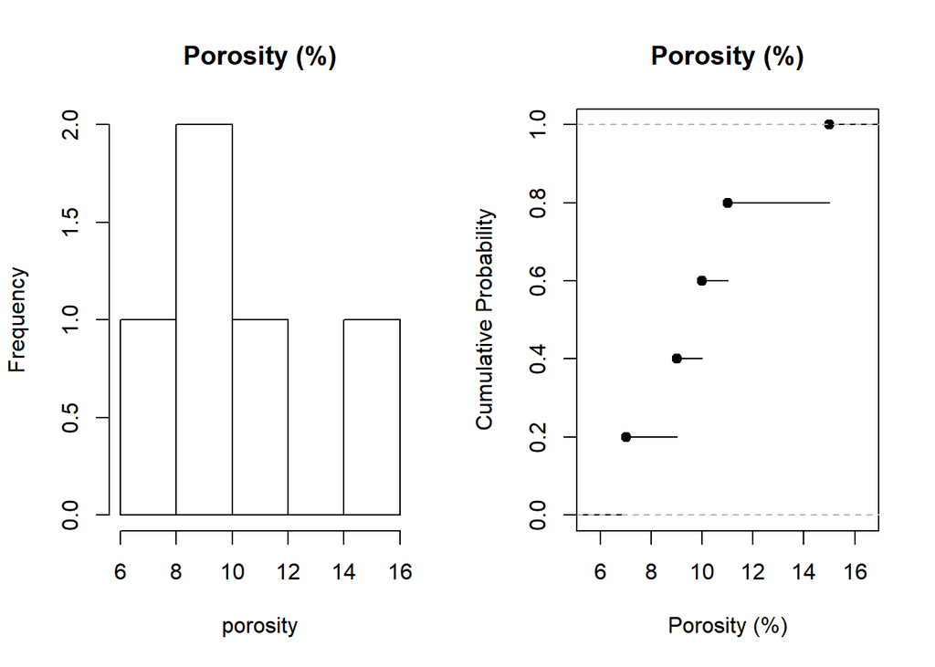

```r
par(mfrow=c(1,2))                              # make an array of plots (2x1)
hist(porosity,main="Porosity (%)")             # plot histogram and CDF
plot(ecdf(porosity),main="Porosity (%)",xlab="Porosity (%)",ylab="Cumulative Probability")
```

#### Next we need to make a statistic function

The bootstrap program requires a function that takes a dataset in an array or vector and vector of indexes, and returns a summary statistic.

For a simple example, lets use the average as our statistic. Here’s our function:

```r
calc_average <- function(d,i=c(1:n)){
  d2 <- d[i]
  return(mean(d2))}
```

Let’s take apart the functon and explain what it does. The first parameter: $d$ is the data vector or array. This contains our samples that we want to resample with bootstrap. The second parameter is an array of indices with the same size of the data vector ($n$ = number of samples). Then what is i=c(1:n)? i is the index vector. The = symbol indicates a default if no second parameter is provided when this program is called. What does c(1:n) make as a default? Let’s check it:

```r
i <- c(1:5)
i
```

```
## [1] 1 2 3 4 5
```

The default is just a vector with indexes in order from 1 to n. Spoiler aleart - for our function, the default if no index vector is provided is to return the dataset average.

#### What does our function do with the index vector?

It builds a new data vector. Let’s test that with a simple index vector of all ones, $[1,1,1,1,1]$.

```r
j = c(1,1,1,1,1)
test_array <- porosity[j]
test_array                                     # vector with 5 values equal to the first element of the porosity vector
```

```
## [1] 7 7 7 7 7
```

The vector of ones results in an array of $5$ values all set to $7%$, the first value in the data vector. So whatever index vector is provided is used to draw $n$ times from the data vector. This is resampling with replacement from our dataset, the basic building block of bootstrap.

#### Let’s check our function

To check our function, if we send this vector of indexes to our function, the average should be equal to the first element $average([7,7,7,7,7]) = 7.

```r
test_average = calc_average(porosity,j)
test_average
```

```
## [1] 7
```

It works! We have a function that takes our data array, an index vector indicating samples from the data vector, makes a new resampled vector and then calculates the average. The boot function will take care of the repeated sampling (make the random index arrays for each sample) and store the statistic (in this case average of five resampled porsity values) realizations, $\overline{\phi^{\ell}}, \forall \ell = 1,\ldots, L$

#### Let’s run bootstrap (boot) now

We are ready to run the bootstrap function (boot) with our dataset and function. We just need to add the decision of how many bootstrapped samples, $L$.

```r
number_boot_samples = 1000                     # this is the number bootstrap samples
boot_por_avg <- boot(data=porosity,statistic=calc_average,R=number_boot_samples)
```

The boot_por_avg is our bootstrap object. As detailed in the boot package docs, it has many useful object members. For example, we can access the bootstrapped samples of average porosity, $\overline{\phi^{\ell}}$, directly as the component vector $t$.

```r
head(boot_por_avg$t,10)
```

```
##       [,1]
##  [1,] 10.6
##  [2,] 10.2
##  [3,]  9.0
##  [4,] 11.4
##  [5,]  9.4
##  [6,]  9.2
##  [7,] 11.4
##  [8,] 10.2
##  [9,] 11.0
## [10,] 10.2
```

#### For visualization let’s plot the bootstrapped samples

The $1,000$ bootstrapped samples of the average porosity from our original 5 data samples is shown below.

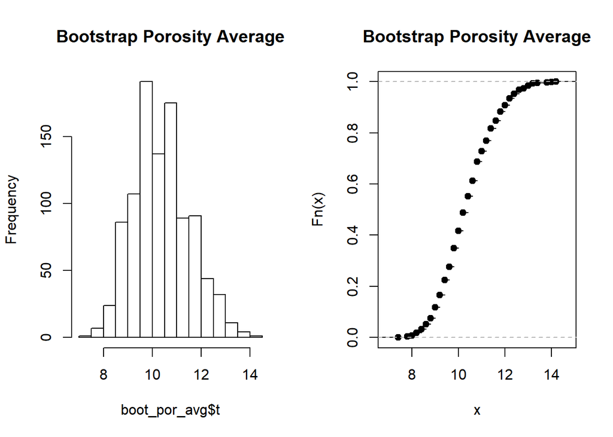

```r
par(mfrow=c(1,2))
hist(boot_por_avg$t,main="Bootstrap Porosity Average")
plot(ecdf(boot_por_avg$t),main="Bootstrap Porosity Average")
```

It may be useful to also look at the summary statistics.

```r
summary(boot_por_avg$t)                        # summary statistics for the bootstrap realizations
```

```
##        V1
##  Min.   : 7.40
##  1st Qu.: 9.60
##  Median :10.40
##  Mean   :10.43
##  3rd Qu.:11.20
##  Max.   :14.20
```

We can confirm that the average of the bootstrap averages is equal to the original data sample average (see above). The bootstrap method, given enough samples, should be unbiased.

#### Could also write out the bootrap realizations to a file

This may be useful for storage for later use or to load into another software platform.

```r
write.csv(boot_por_avg$t,file="bootstrap_avg_por.csv")
```

This was a simple example. There is so much more that can be done. E.g. bootstrap confidence intervals, data weights, multisample etc. See the docs for boot package for more information at https://cran.r-project.org/web/packages/boot/boot.pdf. I hope this was a useful introduction to R. It is a very robust and efficient platform for statistical analysis. You will be amazed with all the powerful tools as we proceed.

Michael J. Pyrcz, P.Eng, Ph.D. Associate Professor, University of Texas at Austin Twitter and GitHub: @GeostatsGuy